# Impact of Weather Events on the Economy and Population Health in U.S.A

# Synopsis

Weather events, such as tornadoes, storms and flood have caused a lot of trouble on public health and economic consequences.

This report will show what type of the weather events have the most impact on population and Economy in U.S.A.

*The data was collected from 1950 to Novenber 2011.*

# Data Processing

## Reading Data

- Data is downloaded from: https://d396qusza40orc.cloudfront.net/repdata%2Fdata%2FStormData.csv.bz2
- The name of data flie is “repdata-data-StormData.csv.bz2”.

```r
Sys.setlocale('LC_ALL', 'English') #If your system is not in English.
```

```
## [1] "LC_COLLATE=English_United States.1252;LC_CTYPE=English_United States.1252;LC_MONETARY=English_United States.1252;LC_NUMERIC=C;LC_TIME=English_United States.1252"
```

```r
stormdata=read.csv("repdata-data-StormData.csv.bz2")
```

## Data Transformations

### Time from 1950 to Nov. 2011

```r
stormdata$BGN_DATE=as.Date(stormdata$BGN_DATE, format = "%m/%d/%Y")
stormdata.after1950= stormdata[(stormdata$BGN_DATE >= "1950-01-01"), ]
str(stormdata.after1950$BGN_DATE)
```

```
##  Date[1:902297], format: "1950-04-18" "1950-04-18" "1951-02-20" "1951-06-08" ...
```

Thus, we have 902297 observations and 37 variables:

```r
dim(stormdata.after1950)
```

```
## [1] 902297     37
```

### Loading required packages

```r
library(Hmisc)
```

```r
library(reshape)
library(car)
library(lattice)
library(ggplot2)
```

### Regulating the events’ types(EVTYPE)

Change the EVTYPE into small letter:

```r
stormdata$EVTYPE=capitalize(tolower(stormdata$EVTYPE))
```

The Data is then processed and analyzed to: - The effect on *population health*: “pop.health” dataframe which is summrized by fatalities and injuries. - The effect on *economy*: “eco.dam” dataframe which is summrized by properity damage and crop damage. - “pop.health.top” and “eco.dam.top”" will show top 10 events.

### The effect on *population health*:

```r
pop.health=aggregate(cbind(FATALITIES, INJURIES) ~ EVTYPE, stormdata, sum)
```

Top 10 for each event:

```r
ph1=head(pop.health[order(-pop.health$FATALITIES),c(1,2) ], 10)
ph2=head(pop.health[order(-pop.health$INJURIES),c(1,3) ], 10)
ph1
```

```
##             EVTYPE FATALITIES
## 758        Tornado       5633
## 116 Excessive heat       1903
## 138    Flash flood        978
## 243           Heat        937
## 418      Lightning        816
## 779      Tstm wind        504
## 154          Flood        470
## 524    Rip current        368
## 320      High wind        248
## 19       Avalanche        224
```

```r
ph2
```

```
##                EVTYPE INJURIES
## 758           Tornado    91346
## 779         Tstm wind     6957
## 154             Flood     6789
## 116    Excessive heat     6525
## 418         Lightning     5230
## 243              Heat     2100
## 387         Ice storm     1975
## 138       Flash flood     1777
## 685 Thunderstorm wind     1488
## 212              Hail     1361
```

Top 10 for the sum:

```r
ph.sum=aggregate(FATALITIES+INJURIES ~ EVTYPE, stormdata, sum)
head(ph.sum[order(-ph.sum[,2]),c(1,2) ], 10)
```

```
##                EVTYPE FATALITIES + INJURIES
## 758           Tornado                 96979
## 116    Excessive heat                  8428
## 779         Tstm wind                  7461
## 154             Flood                  7259
## 418         Lightning                  6046
## 243              Heat                  3037
## 138       Flash flood                  2755
## 387         Ice storm                  2064
## 685 Thunderstorm wind                  1621
## 888      Winter storm                  1527
```

### The effect on *economy*:

First, we convert PROPDMG*PROPDMGEXP and CROPDMG*CROPDMGEXP into the format of “dollar”

```r
stormdata$PROPDMG <- stormdata$PROPDMG * as.numeric(Recode(stormdata$PROPDMGEXP,
    "'0'=1;'1'=10;'2'=100;'3'=1000;'4'=10000;'5'=100000;'6'=1000000;'7'=10000000;'8'=100000000;'B'=1000000000;'h'=100;'H'=100;'K'=1000;'m'=1000000;'M'=1000000;'-'=0;'?'=0;'+'=0",
    as.factor.result = FALSE))
stormdata$CROPDMG <- stormdata$CROPDMG * as.numeric(Recode(stormdata$CROPDMGEXP,
    "'0'=1;'2'=100;'B'=1000000000;'k'=1000;'K'=1000;'m'=1000000;'M'=1000000;''=0;'?'=0",
    as.factor.result = FALSE))
```

Then, we have effect and top10:

```r
eco.dam=aggregate(cbind(PROPDMG, CROPDMG) ~ EVTYPE, stormdata, sum)
```

Top 10 for each event:

```r
head(eco.dam[order(-eco.dam$PROPDMG),c(1,2) ], 10)
```

```
##                EVTYPE   PROPDMG
## 59              Flood 1.447e+11
## 167 Hurricane/typhoon 6.931e+10
## 309           Tornado 5.695e+10
## 260       Storm surge 4.332e+10
## 47        Flash flood 1.682e+10
## 93               Hail 1.574e+10
## 159         Hurricane 1.187e+10
## 317    Tropical storm 7.704e+09
## 372      Winter storm 6.688e+09
## 144         High wind 5.270e+09
```

```r
head(eco.dam[order(-eco.dam$CROPDMG),c(1,3) ], 10)
```

```
##                EVTYPE   CROPDMG
## 59              Flood 5.171e+09
## 226       River flood 5.029e+09
## 175         Ice storm 5.022e+09
## 159         Hurricane 2.689e+09
## 167 Hurricane/typhoon 2.608e+09
## 93               Hail 2.054e+09
## 32            Drought 1.653e+09
## 47        Flash flood 1.388e+09
## 79       Frost/freeze 9.319e+08
## 144         High wind 6.319e+08
```

Top 10 for the sum:

```r
eco.sum=aggregate(PROPDMG+CROPDMG ~ EVTYPE, stormdata, sum)
head(eco.sum[order(-eco.sum[,2]),c(1,2) ], 10)
```

```
##                EVTYPE PROPDMG + CROPDMG
## 59              Flood         1.498e+11
## 167 Hurricane/typhoon         7.191e+10
## 309           Tornado         5.735e+10
## 260       Storm surge         4.332e+10
## 47        Flash flood         1.821e+10
## 93               Hail         1.779e+10
## 159         Hurricane         1.456e+10
## 226       River flood         1.015e+10
## 175         Ice storm         8.967e+09
## 317    Tropical storm         8.156e+09
```

# Results

## Population Health:

### Question:

#### Across the United States, which types of events (as indicated in the EVTYPE variable) are most harmful with respect to population health?

```r
pop.health.top.melt=melt(head(pop.health[order(-pop.health$FATALITIES, -pop.health$INJURIES), ], 10))
```

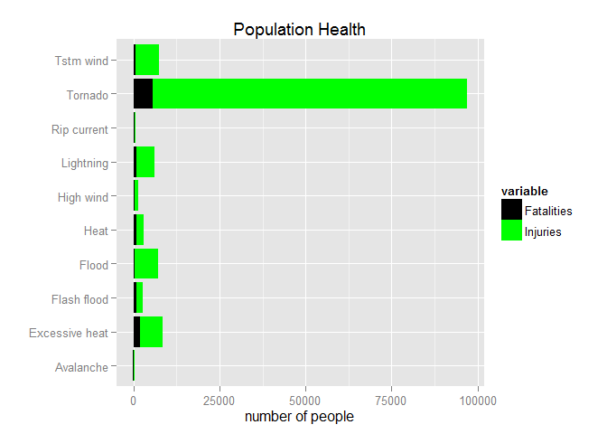

```r
ggplot(pop.health.top.melt, aes(x = EVTYPE, y = value, fill = variable)) + geom_bar(stat = "identity") +
    coord_flip() + ggtitle("Population Health") + labs(x = "", y = "number of people") +
    scale_fill_manual(values = c("black", "green"), labels = c("Fatalities", "Injuries"))
```

## Economic Consequences

### Question:

#### Across the United States, which types of events have the greatest economic consequences?

```r
eco.dam.top.melt=melt(head(eco.dam[order(-eco.dam$PROPDMG, -eco.dam$CROPDMG), ], 10))
```

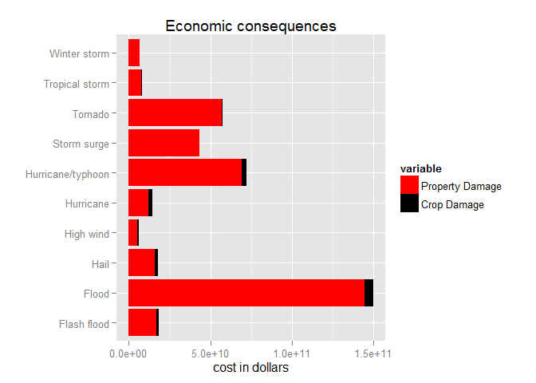

```r
ggplot(eco.dam.top.melt, aes(x = EVTYPE, y = value, fill = variable)) + geom_bar(stat = "identity") +
    coord_flip() + ggtitle("Economic consequences") + labs(x = "", y = "cost in dollars") +
    scale_fill_manual(values = c("red", "black"), labels = c("Property Damage", "Crop Damage"))
```

## From the above plots, we can conclude that:

- The weather event which has the most impact on *population health* is **Tornado**.
- The weather event which has the most impact on *economic consequences* is **Flood**.